# P67-MPDW

Naurah Aathirah Farid_M0401241037

2026-09-24

```r
library(ggplot2)
library(tsibble)
library(tseries)
library(MASS)
library(forecast)
library(TSA)
library(TTR)
library(aTSA)
library(graphics)
library(readxl)
library(lmtest)
library(car)
raw_data <- readxl::read_excel("C:/Users/nau/Downloads/data-mpdw-kel.urutan2.xlsx")

# Mengurutkan data berdasarkan tanggal
raw_data$Date <- as.Date(raw_data$Date)
raw_data <- raw_data[order(raw_data$Date), ]

# Mengambil variabel Harga Rp/g
dataharga <- raw_data$`Harga Rp/g`
dataharga.ts <- ts(dataharga)
```

## 3.1 Eksplorasi Data

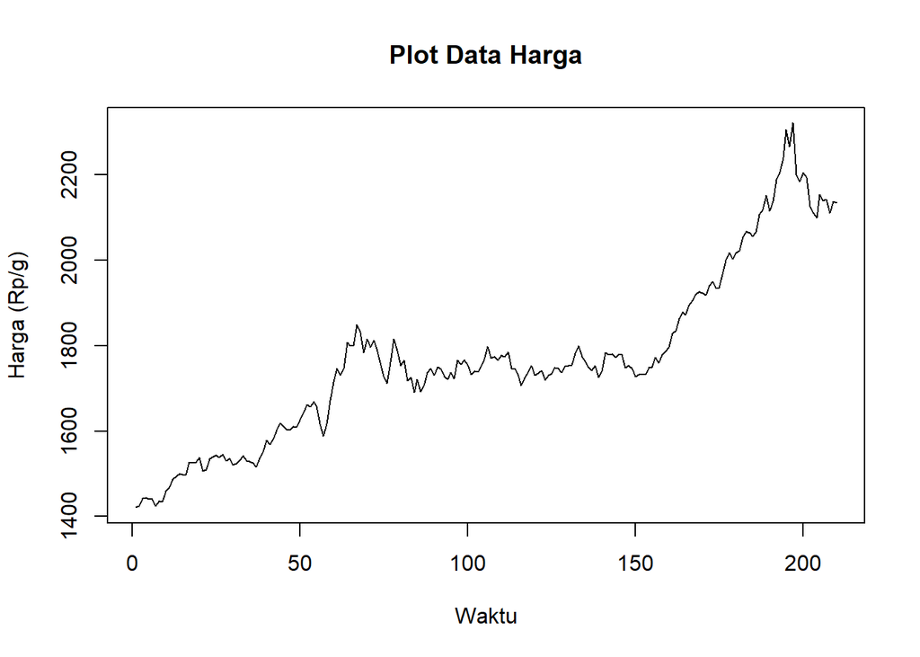

```r
plot.ts(dataharga.ts,
        lty = 1,
        xlab = "Waktu",
        ylab = "Harga (Rp/g)",
        main = "Plot Data Harga")
```

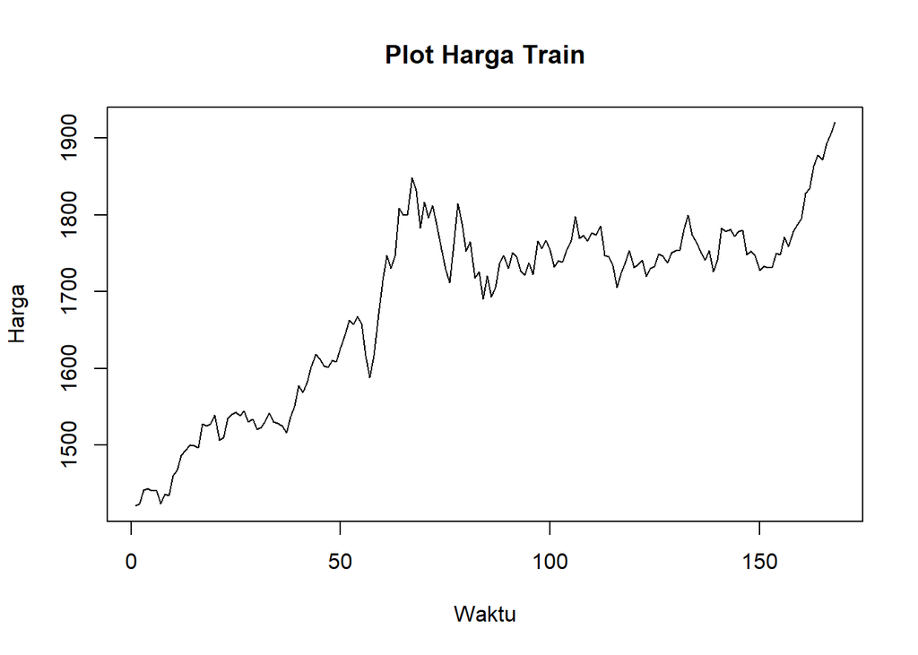

```r
hargatrain <- dataharga[1:168]
train.ts <- ts(hargatrain)
plot.ts(train.ts, lty = 1, xlab = "Waktu", ylab = "Harga", main = "Plot Harga Train")
```

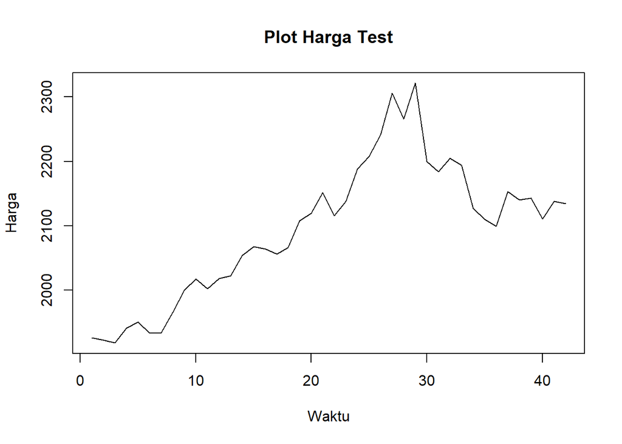

```r
hargatest <- dataharga[169:210]
test.ts <- ts(hargatest)
plot.ts(test.ts, lty = 1, xlab = "Waktu", ylab = "Harga", main = "Plot Harga Test")
```

## 3.2 Uji Stasioneritas Data

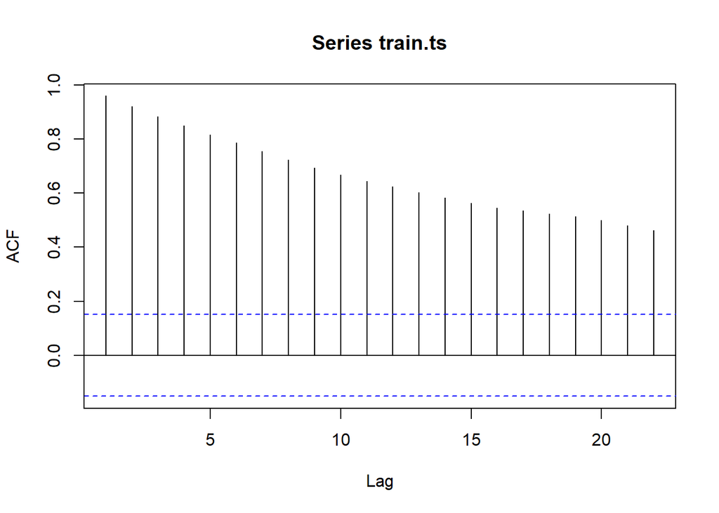

```r
acf(train.ts)
```

Berdasarkan plot ACF, terlihat bahwa plot ACF data menurun secara bertahap (*tails off*). Hal ini menjadi indikasi bahwa data berpotensi belum stasioner dalam rataan.

```r
tseries::adf.test(train.ts)
```

```
##
##  Augmented Dickey-Fuller Test
##
## data:  train.ts
## Dickey-Fuller = -1.9855, Lag order = 5, p-value = 0.5823
## alternative hypothesis: stationary
```

$H_0$ : Data tidak stasioner dalam rataan  
$H_1$ : Data stasioner dalam rataan

Berdasarkan uji ADF tersebut, untuk memastikan kestasioneran yang kuat dan menghilangkan autokorelasi lag tinggi, akan dilanjutkan dengan uji kestasioneran ragam menggunakan Box-Cox.

```r
index <- seq(1:168)

# Box-Cox
bc <- boxcox(train.ts ~ index, lambda = seq(0, 3, by = 0.1))
```

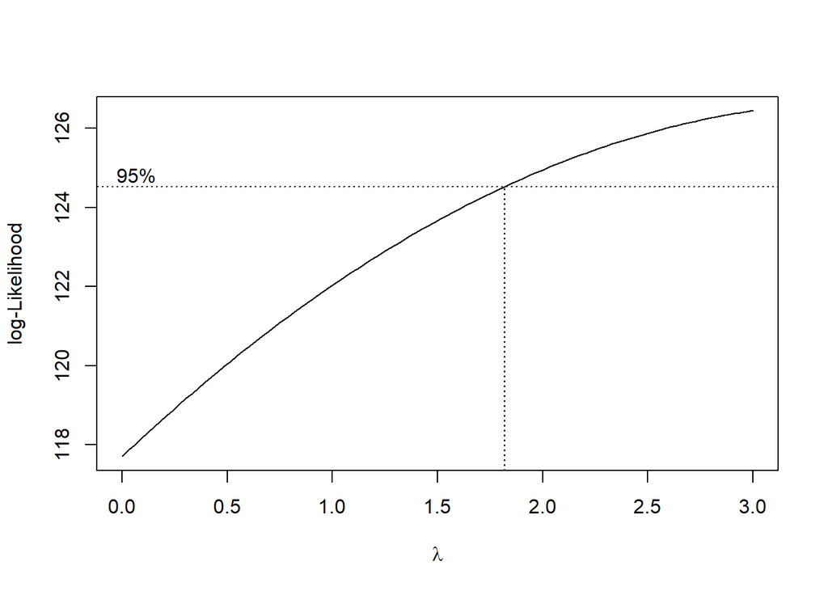

```r
# Nilai lambda optimum (rounded)
lambda_opt <- bc$x[which.max(bc$y)]
lambda_opt
```

```
## [1] 3
```

```r
# Selang kepercayaan 95% untuk lambda
ci_lambda <- bc$x[bc$y > max(bc$y) - 0.5 * qchisq(0.95, df = 1)]

# Batas bawah dan batas atas
ci_lower <- min(ci_lambda)
ci_upper <- max(ci_lambda)

c(Batas_Bawah = ci_lower, Batas_Atas = ci_upper)
```

```
## Batas_Bawah  Batas_Atas
##    1.848485    3.000000
```

## 3.3 Penanganan Ketidakstasioneran Data

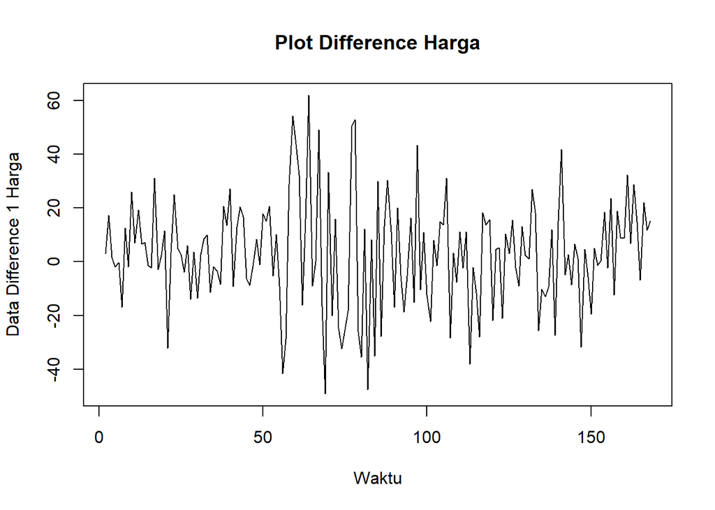

```r
# Differencing pertama
train.diff <- diff(train.ts, differences = 1)

# Plot hasil differencing
plot.ts(train.diff, lty = 1, xlab = "Waktu", ylab = "Data Difference 1 Harga", main = "Plot Difference Harga")
```

Berdasarkan plot data deret waktu, terlihat bahwa data sudah stasioner dalam rataan ditandai dengan data bergerak di sekitar nilai tengah nol.

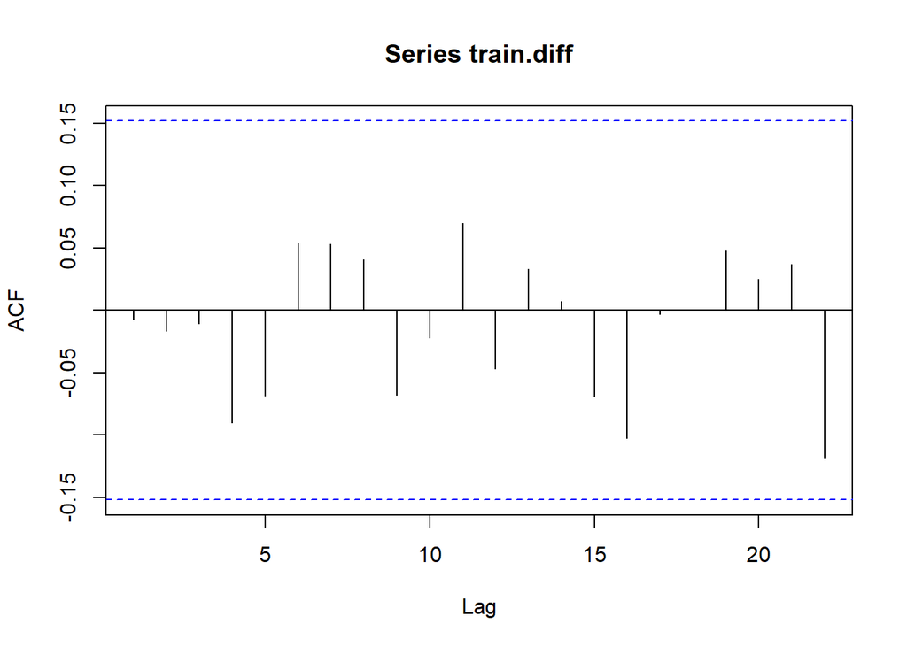

```r
acf(train.diff)
```

```r
tseries::adf.test(train.diff)
```

```
##
##  Augmented Dickey-Fuller Test
##
## data:  train.diff
## Dickey-Fuller = -5.3945, Lag order = 5, p-value = 0.01
## alternative hypothesis: stationary
```

$H_0$ : Data tidak stasioner dalam rataan  
$H_1$ : Data stasioner dalam rataan

Berdasarkan uji ADF tersebut, didapat *p-value* yang sangat kecil ($< 0.05$) sehingga tolak $H_0$ atau data stasioner dalam rataan.

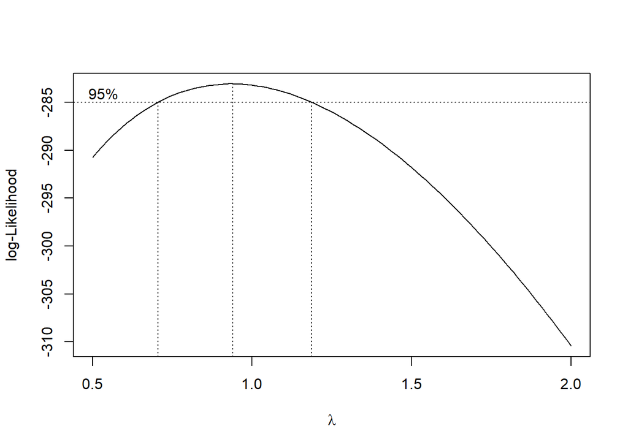

```r
# 1. Sesuaikan panjang index karena differencing menghilangkan 1 observasi awal
index_diff <- seq(1:length(train.diff))

# 2. Cek apakah ada nilai negatif/nol. Jika ada, tambahkan konstanta (c)
min_val <- min(train.diff)

if (min_val <= 0) {
  c <- abs(min_val) + 1
  train.diff_shifted <- train.diff + c
} else {
  train.diff_shifted <- train.diff
}

# 3. Plot Box-Cox pada data yang sudah di-shift
bc_diff <- boxcox(train.diff_shifted ~ index_diff, lambda = seq(0.5, 2, by = 0.1))
```

```r
# 4. Nilai lambda optimum (rounded)
lambda_opt_diff <- bc_diff$x[which.max(bc_diff$y)]
print(paste("Lambda optimum setelah diff:", lambda_opt_diff))
```

```
## [1] "Lambda optimum setelah diff: 0.939393939393939"
```

```r
# 5. Selang kepercayaan 95% untuk lambda
ci_lambda_diff <- bc_diff$x[bc_diff$y > max(bc_diff$y) - 0.5 * qchisq(0.95, df = 1)]

# Batas bawah dan batas atas
ci_lower_diff <- min(ci_lambda_diff)
ci_upper_diff <- max(ci_lambda_diff)

c(Batas_Bawah = ci_lower_diff, Batas_Atas = ci_upper_diff)
```

```
## Batas_Bawah  Batas_Atas
##   0.7121212   1.1818182
```

## 3.4 Identifikasi Model

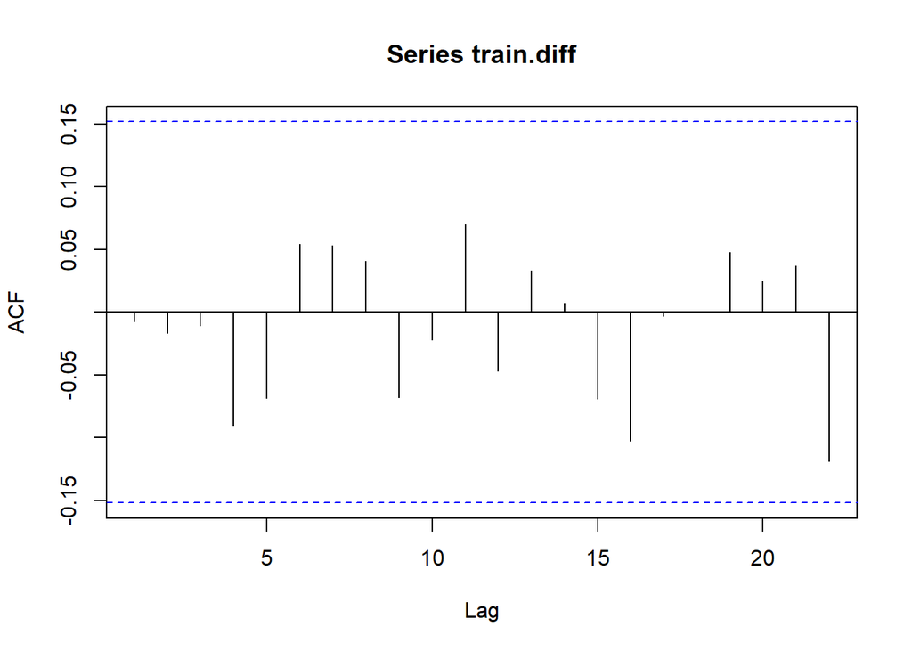

```r
acf(train.diff)
```

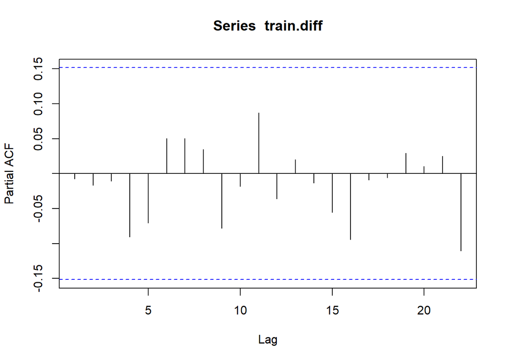

```r
pacf(train.diff)
```

```r
eacf(train.diff)
```

```
## AR/MA
##   0 1 2 3 4 5 6 7 8 9 10 11 12 13
## 0 o o o o o o o o o o o  o  o  o
## 1 x o o o o o o o o o o  o  o  o
## 2 x o o o o o o o o o o  o  o  o
## 3 o x o o o o o o o o o  o  o  o
## 4 x x x x o o o o o o o  o  o  o
## 5 x x x o o o o o o o o  o  o  o
## 6 x o x x o o o o o o o  o  o  o
## 7 x o x o o o o o o o o  o  o  o
```

Identifikasi model menggunakan plot EACF dilakukan dengan melihat ujung segitiga pada pola segitiga nol. Dalam hal ini beberapa model tentatif yang diuji adalah ARIMA(0,1,1), ARIMA(1,1,0), ARIMA(1,1,1), ARIMA(0,1,2), dan ARIMA(2,1,0).

## 3.5 Pendugaan Parameter Model Tentatif

```r
model1.da = Arima(train.diff, order = c(0,0,1), method = "ML")
summary(model1.da)
```

```
## Series: train.diff
## ARIMA(0,0,1) with non-zero mean
##
## Coefficients:
##           ma1    mean
##       -0.0074  2.9895
## s.e.   0.0786  1.5464
##
## sigma^2 = 410.2:  log likelihood = -738.35
## AIC=1482.7   AICc=1482.84   BIC=1492.05
##
## Training set error measures:
##                        ME     RMSE      MAE      MPE     MAPE      MASE
## Training set -0.000201987 20.13191 15.52972 64.03155 149.7709 0.6902542
##                      ACF1
## Training set 8.063732e-05
```

```r
lmtest::coeftest(model1.da)
```

```
##
## z test of coefficients:
##
##             Estimate Std. Error z value Pr(>|z|)
## ma1       -0.0073809  0.0785599 -0.0940  0.92515
## intercept  2.9894849  1.5464359  1.9331  0.05322 .
## ---
## Signif. codes:  0 '***' 0.001 '**' 0.01 '*' 0.05 '.' 0.1 ' ' 1
```

```r
model2.da = Arima(train.diff, order = c(1,0,0), method = "ML")
summary(model2.da)
```

```
## Series: train.diff
## ARIMA(1,0,0) with non-zero mean
##
## Coefficients:
##           ar1    mean
##       -0.0071  2.9894
## s.e.   0.0772  1.5469
##
## sigma^2 = 410.2:  log likelihood = -738.35
## AIC=1482.7   AICc=1482.84   BIC=1492.05
##
## Training set error measures:
##                        ME     RMSE      MAE      MPE     MAPE      MASE
## Training set -0.000133662 20.13192 15.53037 64.03987 149.7778 0.6902831
##                       ACF1
## Training set -0.0001664052
```

```r
lmtest::coeftest(model2.da)
```

```
##
## z test of coefficients:
##
##             Estimate Std. Error z value Pr(>|z|)
## ar1       -0.0071285  0.0772334 -0.0923  0.92646
## intercept  2.9894419  1.5469046  1.9325  0.05329 .
## ---
## Signif. codes:  0 '***' 0.001 '**' 0.01 '*' 0.05 '.' 0.1 ' ' 1
```

```r
model3.da = Arima(train.diff, order = c(1,0,1), method = "ML")
summary(model3.da)
```

```
## Series: train.diff
## ARIMA(1,0,1) with non-zero mean
##
## Coefficients:
```

```
##           ar1      ma1    mean
##       -0.0034  -0.0038  2.9892
## s.e.      NaN      NaN  1.5466
##
## sigma^2 = 412.7:  log likelihood = -738.35
## AIC=1484.7   AICc=1484.94   BIC=1497.17
##
## Training set error measures:
##                       ME     RMSE      MAE      MPE     MAPE     MASE
## Training set 5.17062e-05 20.13191 15.53005 64.03866 149.7696 0.690269
##                       ACF1
## Training set -4.374015e-05
```

```r
lmtest::coeftest(model3.da)
```

```
##
## z test of coefficients:
##
##             Estimate Std. Error z value Pr(>|z|)
## ar1       -0.0034456        NaN     NaN      NaN
## ma1       -0.0038082        NaN     NaN      NaN
## intercept  2.9892455  1.5466338  1.9327  0.05327 .
## ---
## Signif. codes:  0 '***' 0.001 '**' 0.01 '*' 0.05 '.' 0.1 ' ' 1
```

```r
model4.da = Arima(train.diff, order = c(0,0,2), method = "ML")
summary(model4.da)
```

```
## Series: train.diff
## ARIMA(0,0,2) with non-zero mean
##
## Coefficients:
##           ma1      ma2    mean
##       -0.0079  -0.0203  2.9853
## s.e.   0.0774   0.0850  1.5144
##
## sigma^2 = 412.6:  log likelihood = -738.32
## AIC=1484.64   AICc=1484.89   BIC=1497.11
##
## Training set error measures:
##                       ME     RMSE      MAE      MPE     MAPE      MASE
## Training set 0.001340602 20.12845 15.55314 77.14959 138.6214 0.6912953
##                      ACF1
## Training set 0.0002441686
```

```r
lmtest::coeftest(model4.da)
```

```
##
## z test of coefficients:
##
##             Estimate Std. Error z value Pr(>|z|)
## ma1       -0.0078527  0.0774217 -0.1014  0.91921
## ma2       -0.0202547  0.0850253 -0.2382  0.81171
## intercept  2.9853385  1.5143844  1.9713  0.04869 *
## ---
## Signif. codes:  0 '***' 0.001 '**' 0.01 '*' 0.05 '.' 0.1 ' ' 1
```

```r
model5.da = Arima(train.diff, order = c(2,0,0), method = "ML")
summary(model5.da)
```

```
## Series: train.diff
## ARIMA(2,0,0) with non-zero mean
##
## Coefficients:
##           ar1      ar2    mean
##       -0.0073  -0.0165  2.9849
## s.e.   0.0772   0.0772  1.5220
##
## sigma^2 = 412.6:  log likelihood = -738.33
## AIC=1484.65   AICc=1484.9   BIC=1497.12
##
## Training set error measures:
##                     ME     RMSE      MAE      MPE     MAPE      MASE
## Training set 0.0024714 20.12914 15.54821 74.82734 140.5322 0.6910762
##                       ACF1
## Training set -0.0002208227
```

```r
lmtest::coeftest(model5.da)
```

```
##
## z test of coefficients:
##
##             Estimate Std. Error z value Pr(>|z|)
## ar1       -0.0072787  0.0772332 -0.0942  0.92492
## ar2       -0.0164607  0.0771586 -0.2133  0.83107
## intercept  2.9848804  1.5219650  1.9612  0.04986 *
## ---
## Signif. codes:  0 '***' 0.001 '**' 0.01 '*' 0.05 '.' 0.1 ' ' 1
```

## 3.6 Ringkasan AIC

```r
model_tentatif <- data.frame(
  Model = c("ARIMA(0,1,1)", "ARIMA(1,1,0)", "ARIMA(1,1,1)", "ARIMA(0,1,2)", "ARIMA(2,1,0)"),
  AIC   = c(AIC(model1.da), AIC(model2.da), AIC(model3.da), AIC(model4.da), AIC(model5.da)),
  BIC   = c(BIC(model1.da), BIC(model2.da), BIC(model3.da), BIC(model4.da), BIC(model5.da))
)

model_tentatif
```

```
##          Model      AIC      BIC
## 1 ARIMA(0,1,1) 1482.696 1492.050
## 2 ARIMA(1,1,0) 1482.696 1492.050
## 3 ARIMA(1,1,1) 1484.696 1497.168
## 4 ARIMA(0,1,2) 1484.639 1497.111
## 5 ARIMA(2,1,0) 1484.650 1497.122
```

## 3.7 Analisis Sisaan

Model terbaik hasil identifikasi kemudian dicek asumsi sisaannya. Sisaan model ARIMA harus memenuhi asumsi normalitas, kebebasan sisaan, dan kehomogenan ragam.

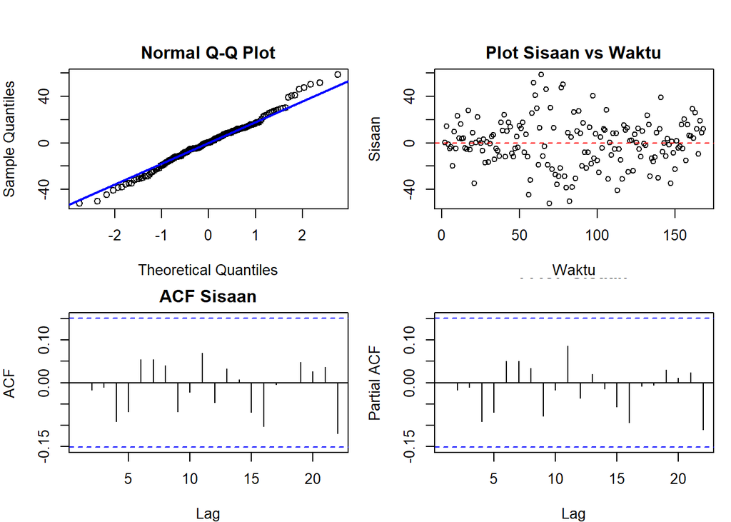

```r
# Menggunakan sisaan dari model1.da (ARIMA(0,1,1))
sisaan.da <- model1.da$residuals

par(mfrow = c(2,2),
    mar = c(4,4,2,1),
    oma = c(0,0,2,0))

# Q-Q Plot
qqnorm(sisaan.da, main = "Normal Q-Q Plot")
qqline(sisaan.da, col = "blue", lwd = 2)

# Plot Sisaan vs Waktu
plot(sisaan.da, type = "p",
     main = "Plot Sisaan vs Waktu",
     xlab = "Waktu", ylab = "Sisaan")
abline(h = 0, col = "red", lty = 2)

# ACF
acf(sisaan.da, main = "ACF Sisaan")

# PACF
pacf(sisaan.da, main = "PACF Sisaan")
```

```r
par(mfrow = c(1,1))
```

```r
# 1) Sisaan Menyebar Normal
ks.test(sisaan.da, "pnorm")
```

```
##
##  Asymptotic one-sample Kolmogorov-Smirnov test
##
## data:  sisaan.da
## D = 0.44711, p-value < 2.2e-16
## alternative hypothesis: two-sided
```

$H_0$ : Sisaan menyebar normal  
$H_1$ : Sisaan tidak menyebar normal

```r
# 2) Sisaan saling bebas/tidak ada autokorelasi
Box.test(sisaan.da, type = "Ljung")
```

```
##
##  Box-Ljung test
##
## data:  sisaan.da
## X-squared = 1.1055e-06, df = 1, p-value = 0.9992
```

$H_0$ : Sisaan saling bebas  
$H_1$ : Sisaan tidak saling bebas

```r
# 3) Sisaan homogen
Box.test((sisaan.da)^2, type = "Ljung")
```

```
##
##  Box-Ljung test
##
## data:  (sisaan.da)^2
## X-squared = 3.7206, df = 1, p-value = 0.05374
```

$H_0$ : Ragam sisaan homogen  
$H_1$ : Ragam sisaan tidak homogen

```r
# 4) Nilai tengah sisaan sama dengan nol
t.test(sisaan.da, mu = 0, conf.level = 0.95)
```

```
##
##  One Sample t-test
##
## data:  sisaan.da
## t = -0.00012927, df = 166, p-value = 0.9999
## alternative hypothesis: true mean is not equal to 0
## 95 percent confidence interval:
##  -3.085213  3.084809
## sample estimates:
##    mean of x
## -0.000201987
```

$H_0$ : Nilai tengah sisaan sama dengan 0  
$H_1$ : Nilai tengah sisaan tidak sama dengan 0

## 3.8 Overfitting

Tahapan selanjutnya adalah *overfitting* yang dilakukan dengan menaikkan orde AR(p) atau MA(q) dari model terbaik.

```r
model_overfit1 = Arima(train.diff, order = c(1,0,1), method = "ML")
summary(model_overfit1)
```

```
## Series: train.diff
## ARIMA(1,0,1) with non-zero mean
##
## Coefficients:
```

```
##           ar1      ma1    mean
##       -0.0034  -0.0038  2.9892
## s.e.      NaN      NaN  1.5466
##
## sigma^2 = 412.7:  log likelihood = -738.35
## AIC=1484.7   AICc=1484.94   BIC=1497.17
##
## Training set error measures:
##                       ME     RMSE      MAE      MPE     MAPE     MASE
## Training set 5.17062e-05 20.13191 15.53005 64.03866 149.7696 0.690269
##                       ACF1
## Training set -4.374015e-05
```

```r
lmtest::coeftest(model_overfit1)
```

```
##
## z test of coefficients:
##
##             Estimate Std. Error z value Pr(>|z|)
## ar1       -0.0034456        NaN     NaN      NaN
## ma1       -0.0038082        NaN     NaN      NaN
## intercept  2.9892455  1.5466338  1.9327  0.05327 .
## ---
## Signif. codes:  0 '***' 0.001 '**' 0.01 '*' 0.05 '.' 0.1 ' ' 1
```

```r
model_overfit2 = Arima(train.diff, order = c(0,0,2), method = "ML")
summary(model_overfit2)
```

```
## Series: train.diff
## ARIMA(0,0,2) with non-zero mean
##
## Coefficients:
##           ma1      ma2    mean
##       -0.0079  -0.0203  2.9853
## s.e.   0.0774   0.0850  1.5144
##
## sigma^2 = 412.6:  log likelihood = -738.32
## AIC=1484.64   AICc=1484.89   BIC=1497.11
##
## Training set error measures:
##                       ME     RMSE      MAE      MPE     MAPE      MASE
## Training set 0.001340602 20.12845 15.55314 77.14959 138.6214 0.6912953
##                      ACF1
## Training set 0.0002441686
```

```r
lmtest::coeftest(model_overfit2)
```

```
##
## z test of coefficients:
##
##             Estimate Std. Error z value Pr(>|z|)
## ma1       -0.0078527  0.0774217 -0.1014  0.91921
## ma2       -0.0202547  0.0850253 -0.2382  0.81171
## intercept  2.9853385  1.5143844  1.9713  0.04869 *
## ---
## Signif. codes:  0 '***' 0.001 '**' 0.01 '*' 0.05 '.' 0.1 ' ' 1
```

## 3.9 Model Terbaik : ARIMA(0,1,1)

```r
model_final = Arima(train.diff, order = c(0,0,1), method = "ML")
summary(model_final)
```

```
## Series: train.diff
## ARIMA(0,0,1) with non-zero mean
##
## Coefficients:
##           ma1    mean
##       -0.0074  2.9895
## s.e.   0.0786  1.5464
##
## sigma^2 = 410.2:  log likelihood = -738.35
## AIC=1482.7   AICc=1482.84   BIC=1492.05
##
## Training set error measures:
##                        ME     RMSE      MAE      MPE     MAPE      MASE
## Training set -0.000201987 20.13191 15.52972 64.03155 149.7709 0.6902542
##                      ACF1
## Training set 8.063732e-05
```

```r
lmtest::coeftest(model_final)
```

```
##
## z test of coefficients:
##
##             Estimate Std. Error z value Pr(>|z|)
## ma1       -0.0073809  0.0785599 -0.0940  0.92515
## intercept  2.9894849  1.5464359  1.9331  0.05322 .
## ---
## Signif. codes:  0 '***' 0.001 '**' 0.01 '*' 0.05 '.' 0.1 ' ' 1
```

## 3.10 Peramalan

```r
# ---FORECAST---
ramalan.da <- forecast::forecast(model_final, h = length(test.ts))
```

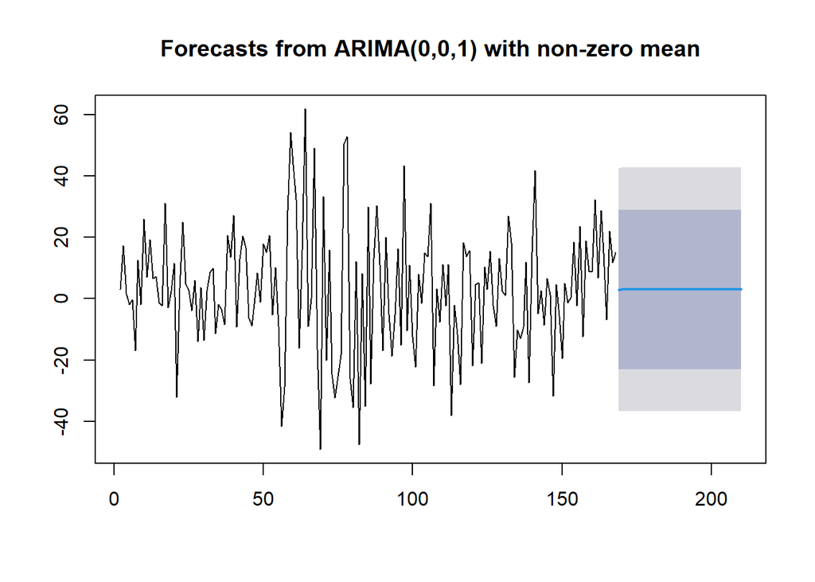

```r
data.ramalan.da <- ramalan.da$mean
plot(ramalan.da)
```

```r
# Inverse differencing
pt_akhir_train <- tail(train.ts, 1)

forecast_inv <- diffinv(data.ramalan.da, differences = 1, xi = pt_akhir_train)
hasil <- forecast_inv[-1]
hasil <- hasil[1:length(test.ts)]

# Bandingkan aktual vs forecast
perbandingan.da <- cbind(
  Aktual   = test.ts,
  Forecast = hasil
)

print(head(perbandingan.da, 10))
```

```
## Time Series:
## Start = 1
## End = 10
## Frequency = 1
##     Aktual Forecast
##  1 1926.66 1923.180
##  2 1922.98 1926.169
##  3 1918.29 1929.159
##  4 1941.05 1932.148
##  5 1950.45 1935.138
##  6 1933.57 1938.127
##  7 1934.09 1941.117
##  8 1965.55 1944.106
##  9 2000.09 1947.096
## 10 2017.17 1950.085
```

```r
# Hitung akurasi
akurasi_test <- accuracy(hasil, test.ts)
akurasi_test
```

```
##                ME     RMSE      MAE      MPE     MAPE      ACF1 Theil's U
## Test set 109.8715 136.6921 111.0926 5.072506 5.135909 0.8934416  4.038315
```

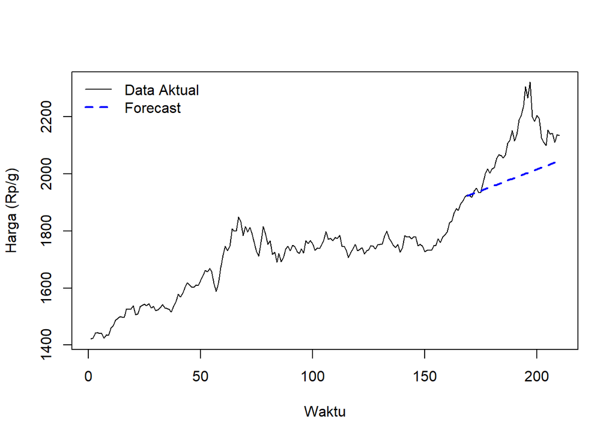

```r
# Plot data
ts.plot(dataharga.ts, col = "black", lty = 1,
        xlab = "Waktu", ylab = "Harga (Rp/g)")

# Garis forecast
lines(169:(168 + length(hasil)), hasil, col = "blue", lty = 2, lwd = 2)
legend("topleft",
       legend = c("Data Aktual", "Forecast"),
       col = c("black", "blue"),
       lty = c(1, 2), lwd = c(1, 2), bty = "n")
```

**1. Karakteristik & Kestasioneran Data:** sData deret waktu harga emas harian (17 Januari 2025 – 6 November 2025, total 210 periode) memiliki tren yang cenderung meningkat (upward trend).

**2. Model Tentatif & Pemilihan Model Terbaik:** Dari pola ACF, PACF, dan matriks EACF pada data hasil differencing, diidentifikasi beberapa kandidat model tentatif, yaitu ARIMA(0,1,1), ARIMA(1,1,0), ARIMA(1,1,1), ARIMA(0,1,2), dan ARIMA(2,1,0).

**3. Diagnostik Sisaan & Overfitting:** **Uji Asumsi Sisaan:** Sisaan model memenuhi asumsi kebebasan antar sisaan / white noise (uji Ljung-Box $p\text{-value} > 0.05$, tidak ada autokorelasi pada sisaan).

Ragam sisaan bersifat homogen (homoskedastisitas).

Nilai tengah sisaan tidak berbeda signifikan dari nol ($p\text{-value} > 0.05$).

**Uji Overfitting:** Penambahan ordo menjadi ARIMA(1,1,1) maupun ARIMA(0,1,2) tidak menghasilkan penurunan nilai AIC yang signifikan dan parameter tambahannya tidak signifikan, membuktikan bahwa ARIMA(0,1,1) sudah optimal.

**4. Kinerja Peramalan (Forecasting):** Peramalan dilakukan pada 42 periode data uji (testing).